# Casas para Alugar

Hanna e Marcos Antônio

26 maio,2021

# 1 Introdução

Utilizamos uma base de dados do kaggle, carregada pelo usuário Rubens Júnior[^1] informando detalhes de casas para alugar no Brasil  
Link para página [Aqui](https://www.kaggle.com/rubenssjr/brasilian-houses-to-rent).  
Escolhemos esta base por conter dados diversificados e pela simplicidade do conteúdo.  
Utilizamos somente as 1000 primeiras linhas da base.

# 2 Limpeza dos dados

Carregando pacotes

```r
library(ggplot2)
library(dplyr)
library(stringr)
library(knitr)
library(rmarkdown)
library(forcats)
library(patchwork)
library(ggExtra)
library(janitor)
```

Limpeza dos dados

```r
Path = 'Moradia/houses_to_rent.csv'
Tabela = read.csv(Path)
Tabela <- Tabela[1:1000,]
Tabela <- Tabela %>% select(-X)
Tabela <- Tabela %>% mutate(city = as.factor(city))
Tabela <- Tabela %>% mutate(floor = as.numeric(as.character(floor)))
Tabela <- Tabela %>% mutate(hoa = str_replace(as.character(hoa),",",""))
Tabela <- Tabela %>% mutate(hoa = as.numeric(str_remove(as.character(hoa),"R\\$")))

Tabela <- Tabela %>% mutate(rent.amount = str_replace(as.character(rent.amount),",",""))
Tabela <- Tabela %>% mutate(rent.amount = floor(as.numeric(str_remove(as.character(rent.amount),"R\\$"))))

Tabela <- Tabela %>% mutate(property.tax = str_replace(as.character(property.tax),",",""))
Tabela <- Tabela %>% mutate(property.tax = floor(as.numeric(str_remove(as.character(property.tax),"R\\$"))))

Tabela <- Tabela %>% mutate(fire.insurance = str_replace(as.character(fire.insurance),",",""))
Tabela <- Tabela %>% mutate(fire.insurance= floor(as.numeric(str_remove(as.character(fire.insurance),"R\\$"))))

Tabela <- Tabela %>% mutate(total = str_replace(as.character(total),",",""))
Tabela <- Tabela %>% mutate(total = floor(as.numeric(str_remove(as.character(total),"R\\$"))))
write.csv(Tabela,"Moradia/Dados limpos")
paged_table(head(Tabela,100))
```

|  | city | area | rooms | bathroom | parking.spaces | floor | animal | furniture | hoa | rent.amount | property.tax | fire.insurance | total |
| --- | --- | --- | --- | --- | --- | --- | --- | --- | --- | --- | --- | --- | --- |
| 1 | 1 | 240 | 3 | 3 | 4 | NA | acept | furnished | 0 | 8000 | 1000 | 121 | 9121 |
| 2 | 0 | 64 | 2 | 1 | 1 | 10 | acept | not furnished | 540 | 820 | 122 | 11 | 1493 |
| 3 | 1 | 443 | 5 | 5 | 4 | 3 | acept | furnished | 4172 | 7000 | 1417 | 89 | 12680 |
| 4 | 1 | 73 | 2 | 2 | 1 | 12 | acept | not furnished | 700 | 1250 | 150 | 16 | 2116 |
| 5 | 1 | 19 | 1 | 1 | 0 | NA | not acept | not furnished | 0 | 1200 | 41 | 16 | 1257 |
| 6 | 1 | 13 | 1 | 1 | 0 | 2 | acept | not furnished | 0 | 2200 | 42 | 28 | 2270 |
| 7 | 1 | 55 | 1 | 1 | 1 | 2 | acept | furnished | 1950 | 5000 | 375 | 64 | 7389 |
| 8 | 1 | 55 | 2 | 2 | 1 | 2 | acept | not furnished | 600 | 1300 | 67 | 17 | 1984 |
| 9 | 1 | 82 | 3 | 1 | 1 | 3 | acept | furnished | 828 | 2000 | 109 | 26 | 2963 |
| 10 | 1 | 32 | 1 | 1 | 1 | 16 | acept | not furnished | 533 | 2900 | 0 | 37 | 3470 |

[output cut: 90 more lines]

Fizemos algumas alterações em células numéricas que estavam em formato `factor` por conter cifrão e outros elementos.

# 3 Medidas

Analisaremos a seguir nossa amostra via tabelas de frequência e medidas tanto de resumo quanto de dispersão.

## 3.1 Analisando dados categóricos

Através da análise individual das variáveis categóricas podemos inferir que um imóvel em nossa amostra muito provavelmente aceita animais, não vem com mobília e é da cidade 1.

### 3.1.1 Animais

```r
paged_table(Tabela %>%
  tabyl(animal) %>%
  adorn_totals(where = c("row")) %>%
  adorn_percentages(denominator = "col") %>%
  adorn_pct_formatting(digits = 2) %>%
  adorn_ns(position = "front"))
```

|  | animal | n | percent |
| --- | --- | --- | --- |
| 1 | acept | 798 (0.8) | 0.798 (79.80%) |
| 2 | not acept | 202 (0.2) | 0.202 (20.20%) |
| 3 | Total | 1000 (1) | 1.000 (100.00%) |

### 3.1.2 Cidade

```r
paged_table(Tabela %>%
  tabyl(city) %>%
  adorn_totals(where = c("row")) %>%
  adorn_percentages(denominator = "col") %>%
  adorn_pct_formatting(digits = 2) %>%
  adorn_ns(position = "front"))
```

|  | city | n | percent |
| --- | --- | --- | --- |
| 1 | 0 | 141 (0.14) | 0.141 (14.10%) |
| 2 | 1 | 859 (0.86) | 0.859 (85.90%) |
| 3 | Total | 1000 (1) | 1.000 (100.00%) |

### 3.1.3 Mobília

```r
paged_table(Tabela %>%
  tabyl(furniture) %>%
  adorn_totals(where = c("row")) %>%
  adorn_percentages(denominator = "col") %>%
  adorn_pct_formatting(digits = 2) %>%
  adorn_ns(position = "front"))
```

|  | furniture | n | percent |
| --- | --- | --- | --- |
| 1 | furnished | 280 (0.28) | 0.28 (28.00%) |
| 2 | not furnished | 720 (0.72) | 0.72 (72.00%) |
| 3 | Total | 1000 (1) | 1.00 (100.00%) |

## 3.2 relação entre as variáveis categóricas

Analisaremos a seguir as relações entre as variáveis categóricas em nossa amostra.

### 3.2.1 Animais x Mobília

```r
paged_table(Tabela %>%
  tabyl(animal,furniture) %>%
  adorn_totals(where = c("row","col")) %>%
  adorn_percentages(denominator = "col") %>%
  adorn_pct_formatting(digits = 2) %>%
  adorn_ns(position = "front"))
```

|  | animal | furnished | not furnished | Total |
| --- | --- | --- | --- | --- |
| 1 | acept | 204 (72.86%) | 594 (82.50%) | 798 (79.80%) |
| 2 | not acept | 76 (27.14%) | 126 (17.50%) | 202 (20.20%) |
| 3 | Total | 280 (100.00%) | 720 (100.00%) | 1000 (100.00%) |

Casas sem mobília geralmente são mais tolerantes com animais, o que é razoável de se pensar, pois animais podem arranhar e danificar a mobília do locador.

### 3.2.2 Animais x Cidade

```r
paged_table(Tabela %>%
  tabyl(animal,city) %>%
  adorn_totals(where = c("row","col")) %>%
  adorn_percentages(denominator = "col") %>%
  adorn_pct_formatting(digits = 2) %>%
  adorn_ns(position = "front"))
```

|  | animal | 0 | 1 | Total |
| --- | --- | --- | --- | --- |
| 1 | acept | 115 (81.56%) | 683 (79.51%) | 798 (79.80%) |
| 2 | not acept | 26 (18.44%) | 176 (20.49%) | 202 (20.20%) |
| 3 | Total | 141 (100.00%) | 859 (100.00%) | 1000 (100.00%) |

Observe que a tolerância aos animais é indiferente à qual cidade o imóvel pertence.

### 3.2.3 Cidade x Mobília

```r
paged_table(Tabela %>%
  tabyl(city,furniture) %>%
  adorn_totals(where = c("row","col")) %>%
  adorn_percentages(denominator = "col") %>%
  adorn_pct_formatting(digits = 2) %>%
  adorn_ns(position = "front"))
```

|  | city | furnished | not furnished | Total |
| --- | --- | --- | --- | --- |
| 1 | 0 | 17 (6.07%) | 124 (17.22%) | 141 (14.10%) |
| 2 | 1 | 263 (93.93%) | 596 (82.78%) | 859 (85.90%) |
| 3 | Total | 280 (100.00%) | 720 (100.00%) | 1000 (100.00%) |

Desta forma concluímos que a proporção de imóveis mobiliados na cidade 1 é consideravelmente superior ao da cidade 0.

## 3.3 Analisando dados numéricos

Algumas variáveis apresentam uma variabilidade dos dados alta como metragem e o valor total para alugar. Outras variáveis apesar de variância alta, por apresentarem outliers apresentam-se menos dispersas.

### 3.3.1 Quartos

```r
paged_table(Tabela %>%
              mutate(rooms = ifelse(rooms >= 5,"5+",rooms) ) %>%
              tabyl(rooms) %>%
              adorn_totals(where = c("row")) %>%
              adorn_percentages(denominator = "col") %>%
              adorn_pct_formatting(digits = 2) %>%
              adorn_ns(position = "front"))
```

|  | rooms | n | percent |
| --- | --- | --- | --- |
| 1 | 1 | 244 (0.24) | 0.244 (24.40%) |
| 2 | 2 | 249 (0.25) | 0.249 (24.90%) |
| 3 | 3 | 330 (0.33) | 0.330 (33.00%) |
| 4 | 4 | 147 (0.15) | 0.147 (14.70%) |
| 5 | 5+ | 30 (0.03) | 0.030 (3.00%) |
| 6 | Total | 1000 (1) | 1.000 (100.00%) |

```r
summary(Tabela$rooms)
```

```
##    Min. 1st Qu.  Median    Mean 3rd Qu.    Max.
##    1.00    2.00    3.00    2.48    3.00    7.00
```

```r
var(Tabela$rooms)
```

```
## [1] 1.276877
```

Observe que mais de 80% dos imóveis da amostra possuem até 3 quartos.Indicando uma baixa variabilidade dos dados.

### 3.3.2 Banheiros

```r
paged_table(Tabela %>%
              mutate(bathroom = ifelse(bathroom >= 5,"5+",bathroom) ) %>%
              tabyl(bathroom) %>%
              adorn_totals(where = c("row")) %>%
              adorn_percentages(denominator = "col") %>%
              adorn_pct_formatting(digits = 2) %>%
              adorn_ns(position = "front"))
```

|  | bathroom | n | percent |
| --- | --- | --- | --- |
| 1 | 1 | 365 (0.36) | 0.365 (36.50%) |
| 2 | 2 | 266 (0.27) | 0.266 (26.60%) |
| 3 | 3 | 152 (0.15) | 0.152 (15.20%) |
| 4 | 4 | 130 (0.13) | 0.130 (13.00%) |
| 5 | 5+ | 87 (0.09) | 0.087 (8.70%) |
| 6 | Total | 1000 (1) | 1.000 (100.00%) |

```r
summary(Tabela$bathroom)
```

```
##    Min. 1st Qu.  Median    Mean 3rd Qu.    Max.
##   1.000   1.000   2.000   2.356   3.000  10.000
```

```r
var(Tabela$bathroom)
```

```
## [1] 2.085349
```

Por mais que tenham imóveis com até 10 banheiros em nossa amostra, observe que mais de 90% se concentram nos imóveis com até 4 banheiros. Podemos perceber a presença desses outliers pela magnitude da variância.

### 3.3.3 vagas de garagem

```r
paged_table(Tabela %>%
              mutate(parking.spaces = ifelse(parking.spaces >= 5,"5+",parking.spaces) ) %>%
              tabyl(parking.spaces) %>%
              adorn_totals(where = c("row")) %>%
              adorn_percentages(denominator = "col") %>%
              adorn_pct_formatting(digits = 2) %>%
              adorn_ns(position = "front"))
```

|  | parking.spaces | n | percent |
| --- | --- | --- | --- |
| 1 | 0 | 190 (0.19) | 0.190 (19.00%) |
| 2 | 1 | 337 (0.34) | 0.337 (33.70%) |
| 3 | 2 | 230 (0.23) | 0.230 (23.00%) |
| 4 | 3 | 112 (0.11) | 0.112 (11.20%) |
| 5 | 4 | 77 (0.08) | 0.077 (7.70%) |
| 6 | 5+ | 54 (0.05) | 0.054 (5.40%) |
| 7 | Total | 1000 (1) | 1.000 (100.00%) |

```r
summary(Tabela$parking.spaces)
```

```
##    Min. 1st Qu.  Median    Mean 3rd Qu.    Max.
##   0.000   1.000   1.000   1.778   2.000   8.000
```

```r
var(Tabela$parking.spaces)
```

```
## [1] 2.525241
```

Um imóvel sem vagas de garagem representa 19% da amostra. Considerando apenas os imóveis com vagas de garagem 70% destes possuem 1 ou 2 vagas.Pelo mesmo argumento dos outliers, a variância está razoavelmente alta, dando uma errada impressão de variabilidade dos dados.

### 3.3.4 andar

```r
paged_table(Tabela %>%
              mutate(floor = cut(Tabela$floor,
                                 breaks = c(0,5,10,15,85) ) ) %>%
              tabyl(floor) %>%
              adorn_totals(where = c("row")) %>%
              adorn_percentages(denominator = "col") %>%
              adorn_pct_formatting(digits = 2) %>%
              adorn_ns(position = "front"))
```

|  | floor | n | percent | valid_percent |
| --- | --- | --- | --- | --- |
| 1 | (0,5] | 333 (0.33) | 0.333 (33.30%) | 0.4416446 (44.16%) |
| 2 | (5,10] | 213 (0.21) | 0.213 (21.30%) | 0.2824934 (28.25%) |
| 3 | (10,15] | 132 (0.13) | 0.132 (13.20%) | 0.1750663 (17.51%) |
| 4 | (15,85] | 76 (0.08) | 0.076 (7.60%) | 0.1007958 (10.08%) |
| 5 | NA | 246 (0.25) | 0.246 (24.60%) | NA (-) |
| 6 | Total | 1000 (1) | 1.000 (100.00%) | 1.0000000 (100.00%) |

```r
summary(Tabela$floor)
```

```
##    Min. 1st Qu.  Median    Mean 3rd Qu.    Max.    NA's
##   1.000   3.000   6.000   7.694  11.000  85.000     246
```

```r
var(Tabela$floor, na.rm = TRUE)
```

```
## [1] 39.94718
```

O exemplo mais marcante na falha da variância em lidar com outliers pode ser conferida neste exemplo. Além disso é interessante resaltar que os imóveis da amostra com andar “NA” serão tratados como casas. Desta forma, quase 25% dos imóveis para alugar são casas. Considerando apenas o apartamentos, quase 90% estão entre o primeiro e o 15º andar.

### 3.3.5 metragem

```r
paged_table(Tabela %>%
              mutate(area = cut(Tabela$area,
                                 breaks = c(0,50,100,150,200,250,900) ) ) %>%
              tabyl(area) %>%
              adorn_totals(where = c("row")) %>%
              adorn_percentages(denominator = "col") %>%
              adorn_pct_formatting(digits = 2) %>%
              adorn_ns(position = "front"))
```

|  | area | n | percent |
| --- | --- | --- | --- |
| 1 | (0,50] | 198 (0.2) | 0.198 (19.80%) |
| 2 | (50,100] | 308 (0.31) | 0.308 (30.80%) |
| 3 | (100,150] | 143 (0.14) | 0.143 (14.30%) |
| 4 | (150,200] | 120 (0.12) | 0.120 (12.00%) |
| 5 | (200,250] | 80 (0.08) | 0.080 (8.00%) |
| 6 | (250,900] | 151 (0.15) | 0.151 (15.10%) |
| 7 | Total | 1000 (1) | 1.000 (100.00%) |

```r
summary(Tabela$area)
```

```
##    Min. 1st Qu.  Median    Mean 3rd Qu.    Max.
##    10.0    58.0   100.0   147.8   198.0   900.0
```

```r
var(Tabela$area)
```

```
## [1] 17498.37
```

### 3.3.6 valor total

```r
# Corrigir notação científica de "total"

paged_table(Tabela %>%
              mutate(total = cut(Tabela$total,breaks = c(500,1500,3000,4500,6000,9000,12000,25000)) ) %>%
              tabyl(total) %>%
              adorn_totals(where = c("row")) %>%
              adorn_percentages(denominator = "col") %>%
              adorn_pct_formatting(digits = 2) %>%
              adorn_ns(position = "front"))
```

|  | total | n | percent |
| --- | --- | --- | --- |
| 1 | (500,1.5e+03] | 89 (0.09) | 0.089 (8.90%) |
| 2 | (1.5e+03,3e+03] | 255 (0.26) | 0.255 (25.50%) |
| 3 | (3e+03,4.5e+03] | 174 (0.17) | 0.174 (17.40%) |
| 4 | (4.5e+03,6e+03] | 103 (0.1) | 0.103 (10.30%) |
| 5 | (6e+03,9e+03] | 148 (0.15) | 0.148 (14.80%) |
| 6 | (9e+03,1.2e+04] | 116 (0.12) | 0.116 (11.60%) |
| 7 | (1.2e+04,2.5e+04] | 115 (0.12) | 0.115 (11.50%) |
| 8 | Total | 1000 (1) | 1.000 (100.00%) |

```r
summary(Tabela$total)
```

```
##    Min. 1st Qu.  Median    Mean 3rd Qu.    Max.
##     660    2550    4279    6026    8598   24890
```

```r
var(Tabela$total)
```

```
## [1] 22836097
```

## 3.4 Variáveis correlacionadas

Como era esperado, valor total e área estão positivamente correlacionados, isto é, quanto maior a área, maior é o valor esperado. No entanto, os dados nos mostram que andar e preço não estão bem correlacionados, isto é, a correlação está relativamente próxima de 0 (0.001).

### 3.4.1 valor total x area

```r
paged_table(Tabela %>%
              mutate(area = cut(Tabela$area,
                                 breaks = c(0,50,100,150,200,250,900) ),
                     total = cut(Tabela$total,breaks = c(500,1500,3000,4500,6000,9000,12000,25000)) ) %>%
              tabyl(total,area) %>%
              adorn_totals(where = c("row","col")) %>%
              adorn_percentages(denominator = "col") %>%
              adorn_pct_formatting(digits = 2) %>%
              adorn_ns(position = "front"))
```

|  | total | (0,50] | (50,100] | (100,150] | (150,200] | (200,250] | (250,900] | Total |
| --- | --- | --- | --- | --- | --- | --- | --- | --- |
| 1 | (500,1.5e+03] | 55 (27.78%) | 33 (10.71%) | 1 (0.70%) | 0 (0.00%) | 0 (0.00%) | 0 (0.00%) | 89 (8.90%) |
| 2 | (1.5e+03,3e+03] | 89 (44.95%) | 137 (44.48%) | 17 (11.89%) | 8 (6.67%) | 3 (3.75%) | 1 (0.66%) | 255 (25.50%) |
| 3 | (3e+03,4.5e+03] | 38 (19.19%) | 67 (21.75%) | 36 (25.17%) | 19 (15.83%) | 8 (10.00%) | 6 (3.97%) | 174 (17.40%) |
| 4 | (4.5e+03,6e+03] | 10 (5.05%) | 30 (9.74%) | 29 (20.28%) | 11 (9.17%) | 7 (8.75%) | 16 (10.60%) | 103 (10.30%) |
| 5 | (6e+03,9e+03] | 5 (2.53%) | 27 (8.77%) | 36 (25.17%) | 33 (27.50%) | 19 (23.75%) | 28 (18.54%) | 148 (14.80%) |
| 6 | (9e+03,1.2e+04] | 1 (0.51%) | 9 (2.92%) | 18 (12.59%) | 33 (27.50%) | 21 (26.25%) | 34 (22.52%) | 116 (11.60%) |
| 7 | (1.2e+04,2.5e+04] | 0 (0.00%) | 5 (1.62%) | 6 (4.20%) | 16 (13.33%) | 22 (27.50%) | 66 (43.71%) | 115 (11.50%) |
| 8 | Total | 198 (100.00%) | 308 (100.00%) | 143 (100.00%) | 120 (100.00%) | 80 (100.00%) | 151 (100.00%) | 1000 (100.00%) |

```r
Covariance <- cov(Tabela$total,Tabela$area)/( sd(Tabela$total) * sd(Tabela$area) )

Covariance
```

```
## [1] 0.6942193
```

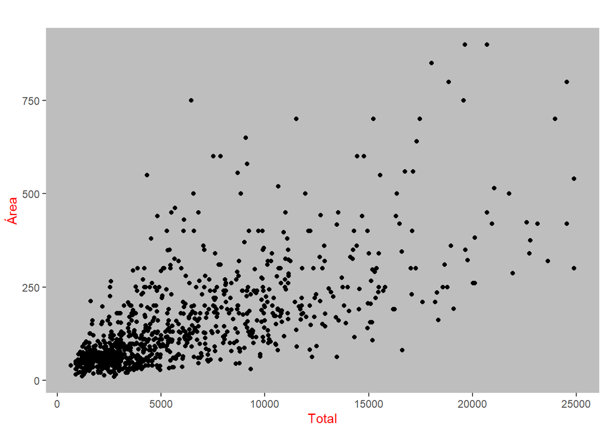

```r
Tabela %>% ggplot(aes(x = total, y = area)) + geom_point() +
    labs(x = "Total", y = "Área", title = "") +
    theme(
    plot.title = element_text(hjust = 0.5),
    axis.title = element_text(color = "red"),
    panel.background = element_rect(fill = "grey"),
    panel.grid = element_blank())
```

0.5 a 0.7 positivo ou negativo indica uma correlação moderada.

### 3.4.2 vagas de garagem x metragem

```r
paged_table(Tabela %>%
              mutate(parking.spaces = ifelse(parking.spaces >= 5,
                                             "5+",parking.spaces),
                     area = cut(Tabela$area,
                                 breaks = c(0,50,100,150,200,250,900) ) ) %>%
              tabyl(parking.spaces,area) %>%
              adorn_totals(where = c("row","col")) %>%
              adorn_percentages(denominator = "col") %>%
              adorn_pct_formatting(digits = 2) %>%
              adorn_ns(position = "front"))
```

|  | parking.spaces | (0,50] | (50,100] | (100,150] | (150,200] | (200,250] | (250,900] | Total |
| --- | --- | --- | --- | --- | --- | --- | --- | --- |
| 1 | 0 | 110 (55.56%) | 54 (17.53%) | 15 (10.49%) | 6 (5.00%) | 0 (0.00%) | 5 (3.31%) | 190 (19.00%) |
| 2 | 1 | 83 (41.92%) | 186 (60.39%) | 34 (23.78%) | 23 (19.17%) | 5 (6.25%) | 6 (3.97%) | 337 (33.70%) |
| 3 | 2 | 5 (2.53%) | 62 (20.13%) | 71 (49.65%) | 45 (37.50%) | 22 (27.50%) | 25 (16.56%) | 230 (23.00%) |
| 4 | 3 | 0 (0.00%) | 4 (1.30%) | 21 (14.69%) | 30 (25.00%) | 26 (32.50%) | 31 (20.53%) | 112 (11.20%) |
| 5 | 4 | 0 (0.00%) | 2 (0.65%) | 2 (1.40%) | 11 (9.17%) | 22 (27.50%) | 40 (26.49%) | 77 (7.70%) |
| 6 | 5+ | 0 (0.00%) | 0 (0.00%) | 0 (0.00%) | 5 (4.17%) | 5 (6.25%) | 44 (29.14%) | 54 (5.40%) |
| 7 | Total | 198 (100.00%) | 308 (100.00%) | 143 (100.00%) | 120 (100.00%) | 80 (100.00%) | 151 (100.00%) | 1000 (100.00%) |

```r
Covariance <- cov(Tabela$parking.spaces,Tabela$area)/( sd(Tabela$parking.spaces) * sd(Tabela$area) )

Covariance
```

```
## [1] 0.7225513
```

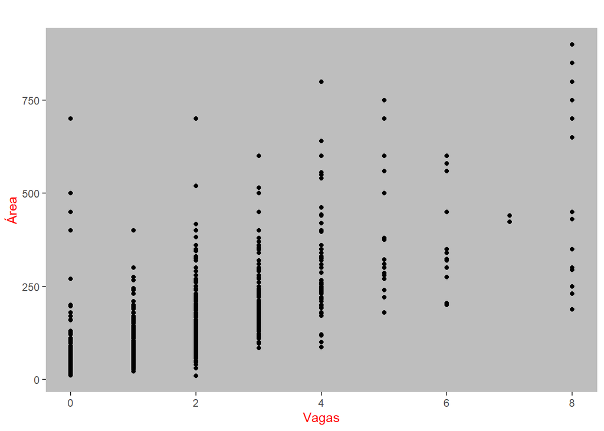

```r
Tabela %>% ggplot(aes(x = parking.spaces, y = area)) + geom_point() +
    labs(x = "Vagas", y = "Área", title = "") +
    theme(
    plot.title = element_text(hjust = 0.5),
    axis.title = element_text(color = "red"),
    panel.background = element_rect(fill = "grey"),
    panel.grid = element_blank())
```

0.7 a 0.9 positivo ou negativo indica uma correlação forte.

### 3.4.3 valor total x andar

```r
paged_table(Tabela %>%
              mutate(floor = cut(Tabela$floor,
                                 breaks = c(0,5,10,15,85) ),
                     total = cut(Tabela$total,
                                          breaks = c(500,1500,3000,4500,6000,9000,12000,25000))) %>%
              tabyl(total,floor) %>%
              adorn_totals(where = c("row","col")) %>%
              adorn_percentages(denominator = "col") %>%
              adorn_pct_formatting(digits = 2) %>%
              adorn_ns(position = "front"))
```

|  | total | (0,5] | (5,10] | (10,15] | (15,85] | NA_ | Total |
| --- | --- | --- | --- | --- | --- | --- | --- |
| 1 | (500,1.5e+03] | 43 (12.91%) | 7 (3.29%) | 2 (1.52%) | 1 (1.32%) | 36 (14.63%) | 89 (8.90%) |
| 2 | (1.5e+03,3e+03] | 99 (29.73%) | 56 (26.29%) | 27 (20.45%) | 21 (27.63%) | 52 (21.14%) | 255 (25.50%) |
| 3 | (3e+03,4.5e+03] | 61 (18.32%) | 35 (16.43%) | 26 (19.70%) | 13 (17.11%) | 39 (15.85%) | 174 (17.40%) |
| 4 | (4.5e+03,6e+03] | 27 (8.11%) | 22 (10.33%) | 20 (15.15%) | 6 (7.89%) | 28 (11.38%) | 103 (10.30%) |
| 5 | (6e+03,9e+03] | 40 (12.01%) | 40 (18.78%) | 21 (15.91%) | 10 (13.16%) | 37 (15.04%) | 148 (14.80%) |
| 6 | (9e+03,1.2e+04] | 32 (9.61%) | 25 (11.74%) | 18 (13.64%) | 13 (17.11%) | 28 (11.38%) | 116 (11.60%) |
| 7 | (1.2e+04,2.5e+04] | 31 (9.31%) | 28 (13.15%) | 18 (13.64%) | 12 (15.79%) | 26 (10.57%) | 115 (11.50%) |
| 8 | Total | 333 (100.00%) | 213 (100.00%) | 132 (100.00%) | 76 (100.00%) | 246 (100.00%) | 1000 (100.00%) |

```r
Covariance <- cov(Tabela$total, !is.na(Tabela$floor) )/( sd(Tabela$total) * sd( Tabela$floor, na.rm = TRUE))

Covariance
```

```
## [1] 0.001760456
```

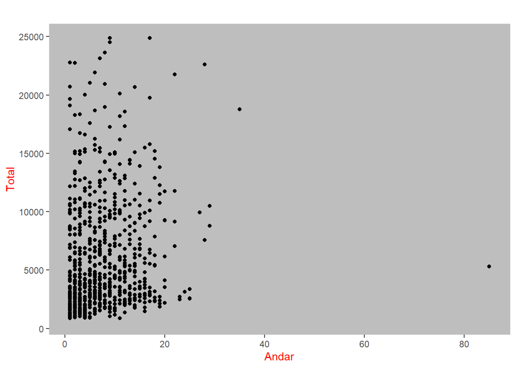

```r
Tabela %>% ggplot(aes(x = floor, y = total)) + geom_point() +
    labs(x = "Andar", y = "Total", title = "") +
    theme(
    plot.title = element_text(hjust = 0.5),
    axis.title = element_text(color = "red"),
    panel.background = element_rect(fill = "grey"),
    panel.grid = element_blank())
```

0 a 0.3 positivo ou negativo indica uma correlação desprezível.

```r
Covariance <- cov(Tabela$area,Tabela$floor, use = 'na.or')/( sd(Tabela$area) * sd( Tabela$floor, na.rm = TRUE ) )

Covariance
```

```
## [1] 0.06296963
```

```r
Covariance <- cov(Tabela$rooms, Tabela$floor, use = 'na.or')/( sd(Tabela$rooms) * sd( Tabela$floor, na.rm = TRUE ) )

Covariance
```

```
## [1] 0.01298221
```

# 4 Visualizações

```r
paged_table( Tabela %>% count(floor) %>% arrange(desc(floor)),
             options = list(rows.print = 5))
```

| floor | n |
| --- | --- |
| 85 | 1 |
| 35 | 1 |
| 29 | 2 |
| 28 | 2 |
| 27 | 1 |
| 25 | 4 |
| 24 | 1 |
| 23 | 2 |
| 22 | 4 |
| 20 | 7 |

[output cut: 20 more lines]

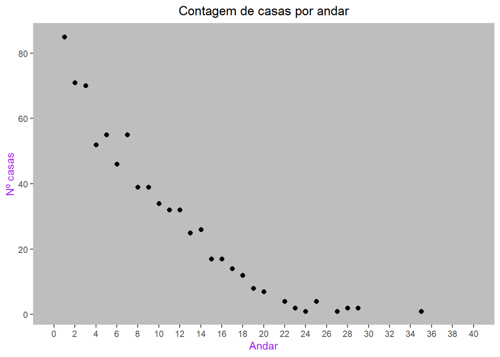

```r
Tabela %>% ggplot(aes(floor)) + geom_point(stat = 'count', size = 2)  +
  coord_cartesian(xlim = c(0, 40)) +
  scale_x_continuous(breaks = seq(0, 40, 2)) +
  labs(x = "Andar", y = "Nº casas", title = "Contagem de casas por andar") +
    theme(
    plot.title = element_text(hjust = 0.5),
    axis.title = element_text(color = "purple"),
    panel.background = element_rect(fill = "grey"),
    panel.grid = element_blank())
```

Quanto maior o andar menos imóveis para alugar, o que era esperado.

Vamos a algumas estatísticas de valores

abaixo o boxplot com as variáveis numéricas nos darão uma ideia de dispersão, média e quantis.

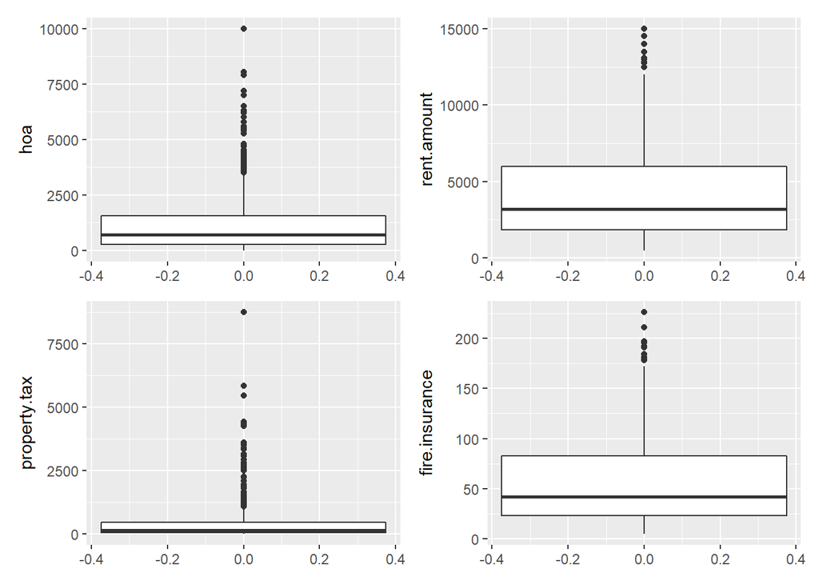

```r
p1 <- Tabela %>% ggplot(aes(y = hoa)) + geom_boxplot()
p2 <- Tabela %>% ggplot(aes(y = rent.amount)) + geom_boxplot()
p3 <- Tabela %>% ggplot(aes(y = property.tax)) + geom_boxplot()
p4 <- Tabela %>% ggplot(aes(y = fire.insurance)) + geom_boxplot()
p1+p2+p3+p4
```

Percebe-se que o valor do aluguel tende a ser mais bem distribuído que as outras cobranças.

Vamos criar uma nova coluna “preço_ relativo_m2” obtida pela razão entre o total em valor e a área. Vejamos os que possuem o $m^2$ acima de R$100,00.

```r
Tabela <- Tabela %>% mutate(preço_m2 = total/area)
paged_table( head(Tabela) )
```

|  | city | area | rooms | bathroom | parking.spaces | floor | animal | furniture | hoa | rent.amount | property.tax | fire.insurance | total | preço_m2 |
| --- | --- | --- | --- | --- | --- | --- | --- | --- | --- | --- | --- | --- | --- | --- |
| 1 | 1 | 240 | 3 | 3 | 4 | NA | acept | furnished | 0 | 8000 | 1000 | 121 | 9121 | 38.00417 |
| 2 | 0 | 64 | 2 | 1 | 1 | 10 | acept | not furnished | 540 | 820 | 122 | 11 | 1493 | 23.32812 |
| 3 | 1 | 443 | 5 | 5 | 4 | 3 | acept | furnished | 4172 | 7000 | 1417 | 89 | 12680 | 28.62302 |
| 4 | 1 | 73 | 2 | 2 | 1 | 12 | acept | not furnished | 700 | 1250 | 150 | 16 | 2116 | 28.98630 |
| 5 | 1 | 19 | 1 | 1 | 0 | NA | not acept | not furnished | 0 | 1200 | 41 | 16 | 1257 | 66.15789 |
| 6 | 1 | 13 | 1 | 1 | 0 | 2 | acept | not furnished | 0 | 2200 | 42 | 28 | 2270 | 174.61538 |

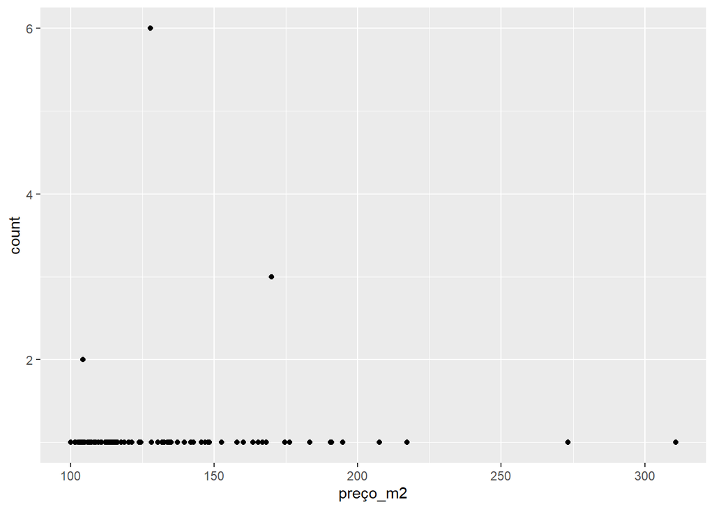

```r
Tabela %>% filter(preço_m2 >=100) %>% ggplot(aes(preço_m2))  + geom_point(stat = 'count')
```

vejamos se o preço por $m^2$ tem alguma relação com a cidade.

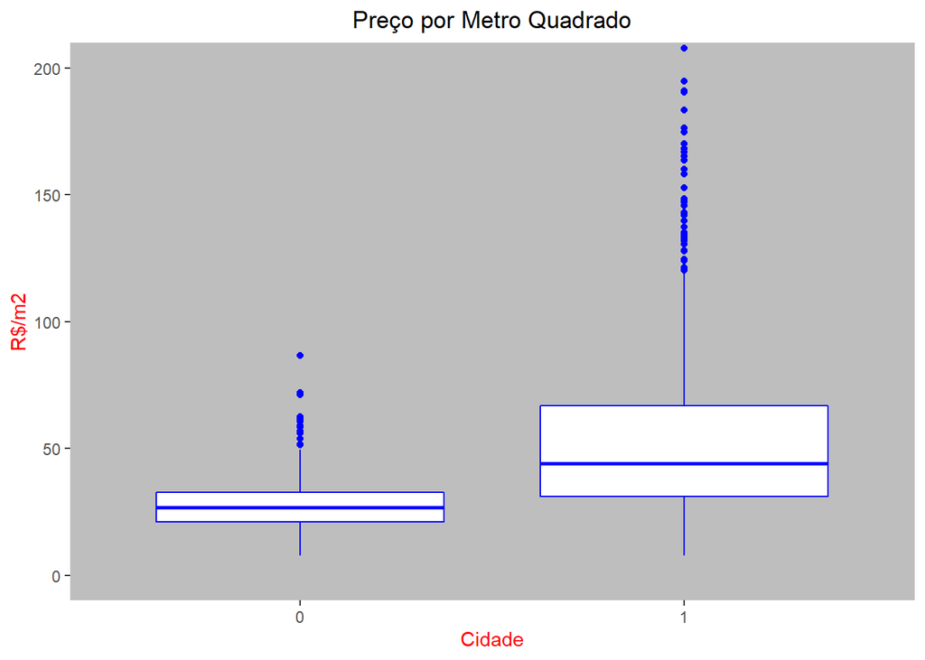

```r
Tabela %>% group_by(city) %>% ggplot(aes(x = city, y = preço_m2)) + geom_boxplot(color = "blue") +
  coord_cartesian(ylim = c(0, 200)) +
  labs(x = "Cidade", y = "R$/m2", title = "Preço por Metro Quadrado") +
    theme(
    plot.title = element_text(hjust = 0.5),
    axis.title = element_text(color = "red"),
    panel.background = element_rect(fill = "grey"),
    panel.grid = element_blank())
```

A cidade 1 tem o $m^2$ mais caro que a cidade 0, no entanto a cidade 0 tem uma distribuição de preços mais regular.

```r
paged_table(Tabela %>% count(animal))
```

| animal | n |
| --- | --- |
| acept | 798 |
| not acept | 202 |

```r
paged_table(Tabela %>% filter(rent.amount > 12000) %>% count(animal))
```

| animal | n |
| --- | --- |
| acept | 47 |
| not acept | 7 |

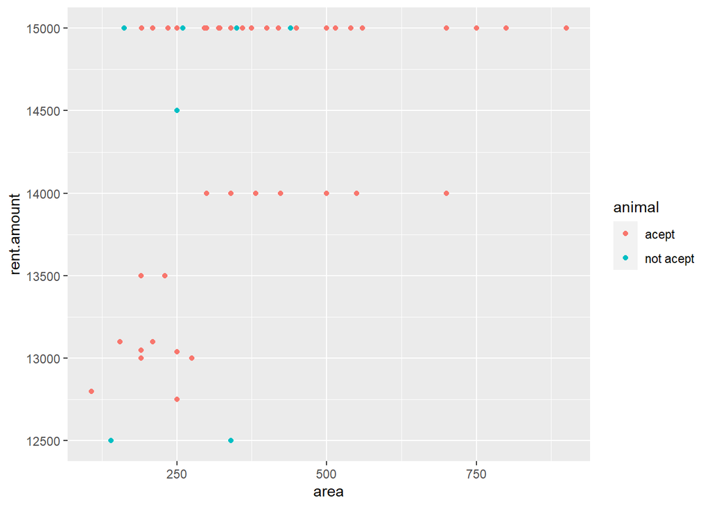

```r
Tabela %>% filter(rent.amount > 12000) %>%
  ggplot(aes(x = area, y = rent.amount, colour = animal)) + geom_point()
```

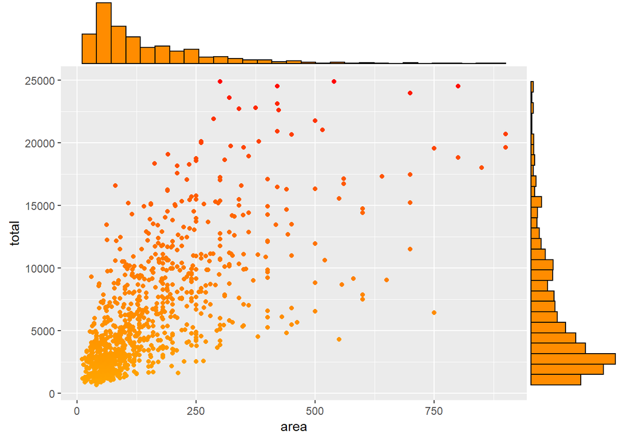

```r
graf <- Tabela %>%
  filter( !is.na(Tabela) ) %>%
  ggplot() +
  geom_point(mapping = aes(x = area, y = total, color = total)) +
  scale_color_gradient(low = "orange", high = "red") +
  theme(legend.position="none")

graf <- ggMarginal(graf, type="histogram",fill = "darkorange")


show(graf)
```

Observe que existe um ponto de concentração de imóveis na faixa de valor total para alugar até 5 mil e área de até 150 m^2 .

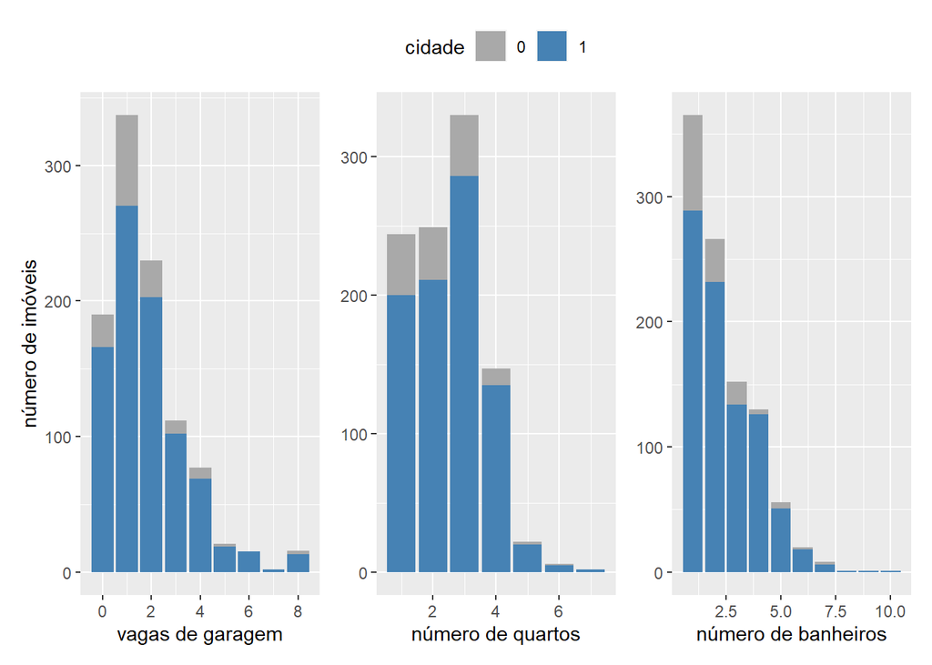

```r
colors = c("darkgray","steelblue")

vagas <- Tabela %>% ggplot( aes(x = parking.spaces, fill = city ) ) +
  geom_bar(show.legend = FALSE) +
  labs(x = "vagas de garagem", y = "número de imóveis") +
  scale_fill_manual(values = colors)

quartos <- Tabela %>% ggplot( aes(x = rooms, fill = city ) ) +
  geom_bar() +
  labs(x = "número de quartos") +
  scale_fill_manual(values = colors,
                    name = "cidade",
                    labels = c("0", "1")) +
  theme(axis.title.y = element_blank(),
        legend.position="top")

banheiros <- Tabela %>% ggplot( aes(x = bathroom, fill = city ) ) +
  geom_bar(show.legend = FALSE) +
  labs(x = "número de banheiros") +
  scale_fill_manual(values = colors) +
  theme(axis.title.y = element_blank() )

vagas + quartos + banheiros
```

Podemos observar nos gráficos que por mais que o número de imóveis para alugar da cidade 0 seja bem menor do que o número de imóveis da cidade 1, as variáveis observadas aparentam ser indiferentes quanto a qual cidade pertencem.

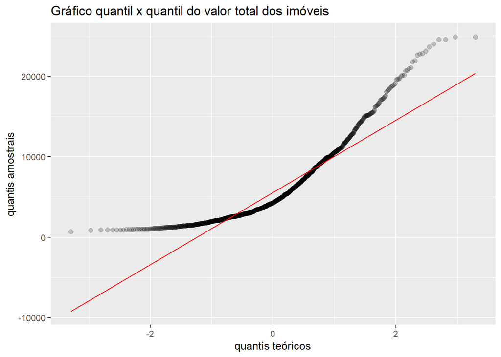

```r
Tabela %>%
  ggplot(aes(sample = total) ) +
  stat_qq(color = "black",
          fill = "gray",
          alpha = 1/5,
          size = 2) +
  stat_qq_line(color = "red") +
  labs(title = "Gráfico quantil x quantil do valor total dos imóveis",
       x = "quantis teóricos",
       y = "quantis amostrais")
```

# 5 Bibliotecas utilizadas

Grande parte dos comandos foram feitos utilizando `ggplot2`,`dplyr`. `stringr` auxiliou na limpeza dos dados, `forcats`,`knitr` e `rmarkdown` foram usadas para a construção de estruturas de dados categóricos. `patchwork` para juntar gráficos distintos. `ggExtra` para plotar gráficos marginais. `janitor` para as tabelas de frequência.

# 6 Divisão do Trabalho e Curva de Aprendizado

- Limpeza de dados : Marcos
- Medidas : análises 3.1, 3.2, 3.3 Hanna e 3.4 Marcos
- Visualizações : 6 primeiras Marcos e 3 últimas Hanna

Hanna: “Foi interessante no sentido de aplicabilidade de cada medida e tipo de gráfico em cada contexto a ser analisado, ao mesmo tempo que produtivo do ponto de vista de familiarização com as possibilidades de customização do ggplot2 e de usabilidade do pacote janitor para as tabelas de frequência”

Marcos : “Familiarização com o tidyverse ggplot e rbase. Além disso foi inportante pro aprendizado de Rmarkdown e para a exploração de dados”

Github: https://github.com/HannaRF/Exploratory_Data_Analysis

# 7 Referências

- Livro de R [consultado](https://livro.curso-r.com/).
- Livro de auxílio com para [tabelas](https://www.ime.usp.br/~pam/scriptsR.html).
- Imagem do cabeçalho https://image.freepik.com/vetores-gratis/uma-casa-de-dois-andares_1308-16176.jpg.
[^1]: Link para a página do usuário que carregou a base [aqui](http://www.rubenssjr.com.br/)